# Time series analysis project

Sofia Davoli

3/1/2021

## Data Preprocessing and Exploration

Data preprocessing consist in fixing 2 missing value in this time series (TS). Missing values are on 29-03-2020 and 31-03-2019 which represents Italian daylight savings time (ora legale). Missing imputation has been applied by substituting the value with the one of the previous hour, considering that values at 3am seems to be quite constant.

For further exploration, weekly TS has been created by setting frequency parameter to 168 (24 hours* 7 days).

Finally TS has been scaled to optimize models training.

Daily plot (1) shows a clear daily seasonality but from Weekly plot (2) no particular weekly trend appears, in fact there are no significant differences in values from 1st day of the week from the last day. We can assume that weekend days have no significant influence on TS. Daily seasonality is confirmed by plot 6 (automatic TS decomposition) in which appear a seasonal24 decomposition.

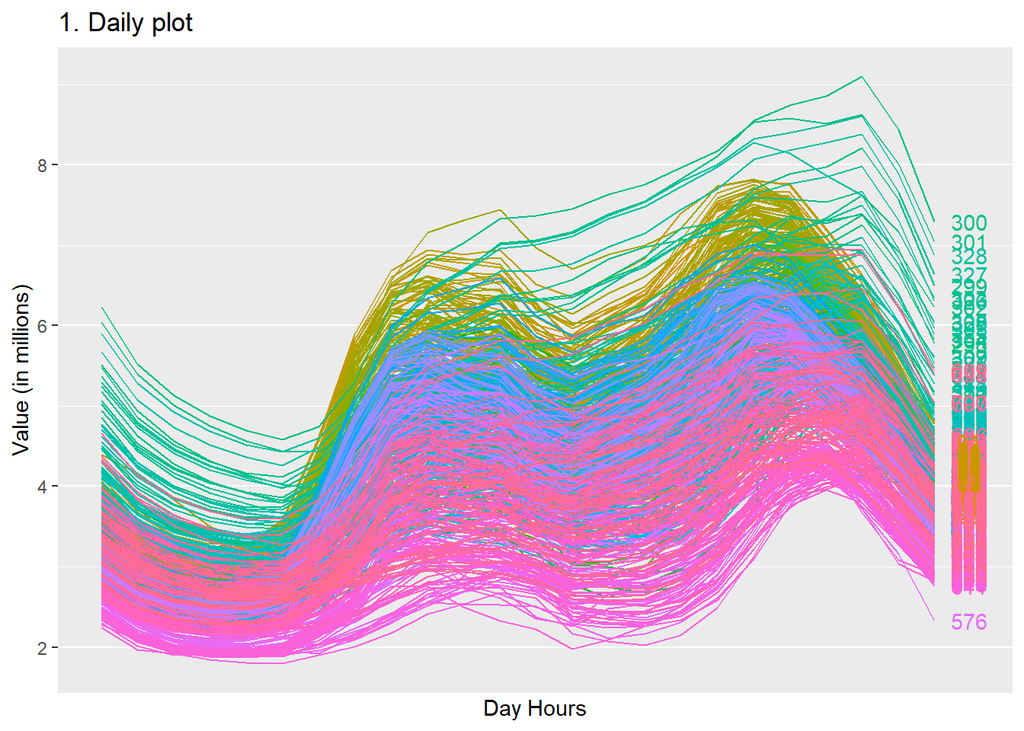

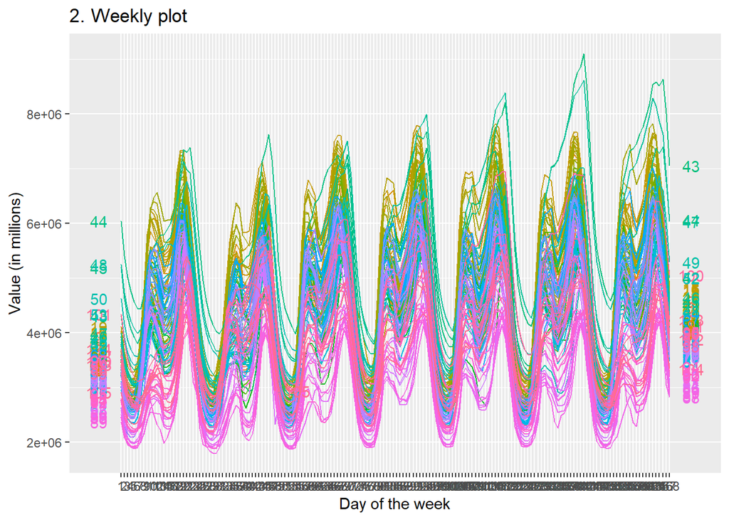

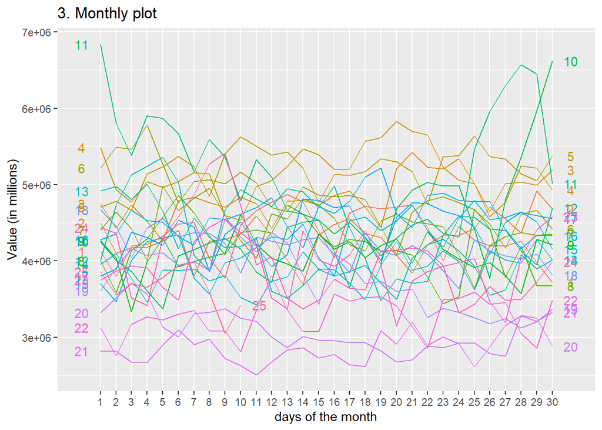

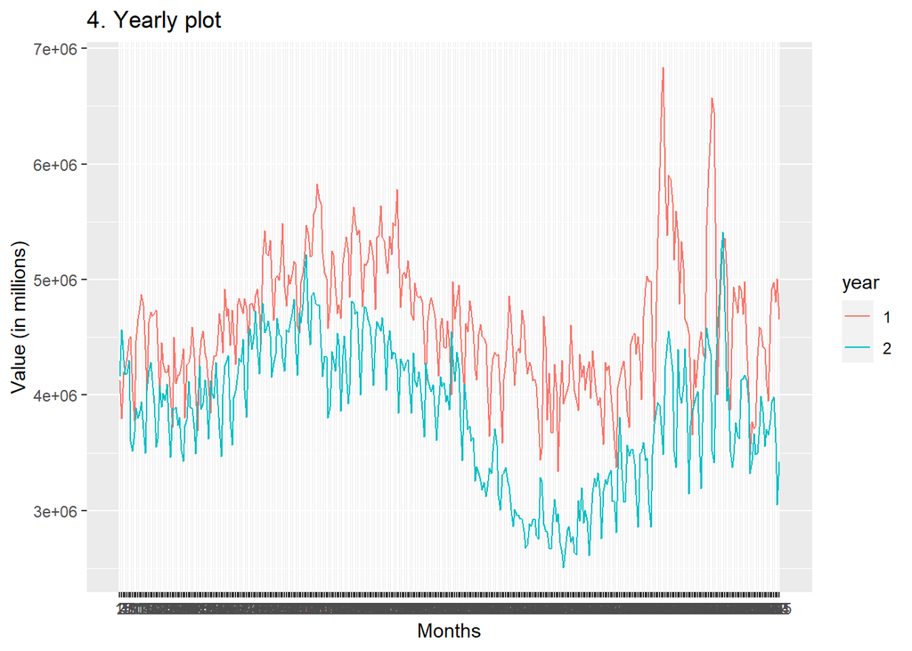

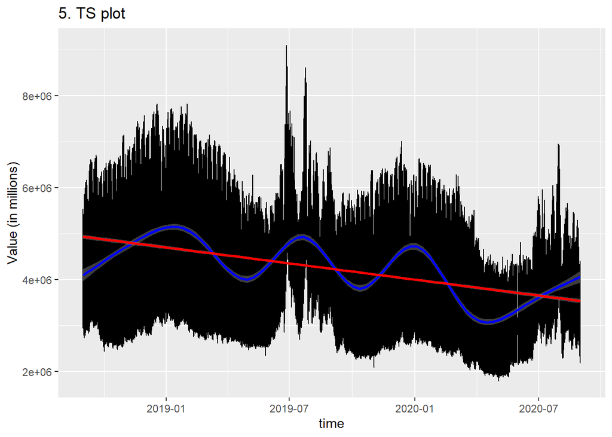

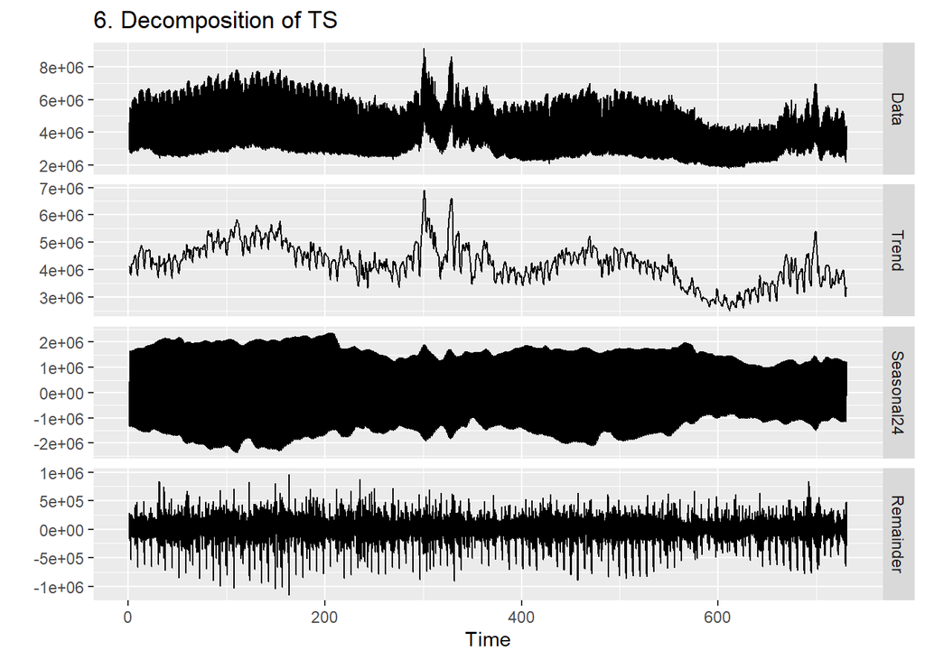

## Arima and Naive methods

Training and validation set for arima models are created respectively using 80% - 20% of data. Models are trined and evaluated on scaled data.

```r
train_arima <- ts(ts_stand[1:as.integer(nrow(ts)*0.8), ],
                  frequency = 24)
validation_arima <- ts(ts_stand[(1 + as.integer(nrow(ts)*0.8)) :                      nrow(ts), ], frequency = 24)
```

Some preliminary assumptions are made based on ACF and PACF results.

ACF plot shows a clear seasonality of period 24, in fact the autocorrelations is higher for the seasonal lags (at multiples of 24) than for other lags. PACF plot suggest an AR(2),AR(3) or AR(5) model since the number of non-zero partial autocorrelations (in this case 5) gives the order of the AR model.

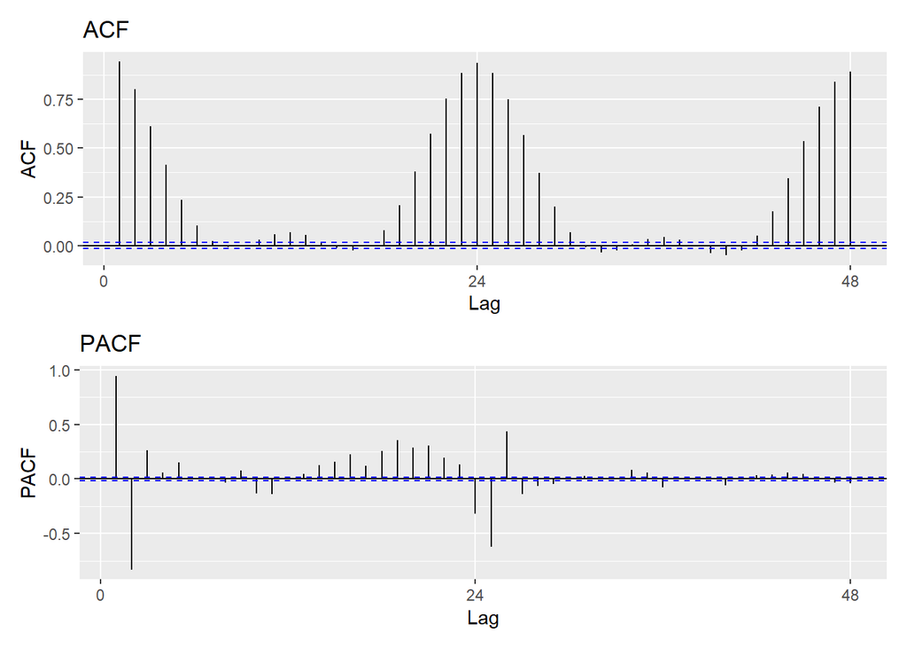

To identify the best model Box-jenkins methodology is applied.

2 - As previously seen, the TS show a strong seasonality component. To remove it, a seasonal differences at lag 24 is taken. A Box-Ljung test reject H0 of White Noise.

This results suggest the use of a SARIMA model with daily seasonality, 2 integration and AR component equal to 2, 3 or 5.

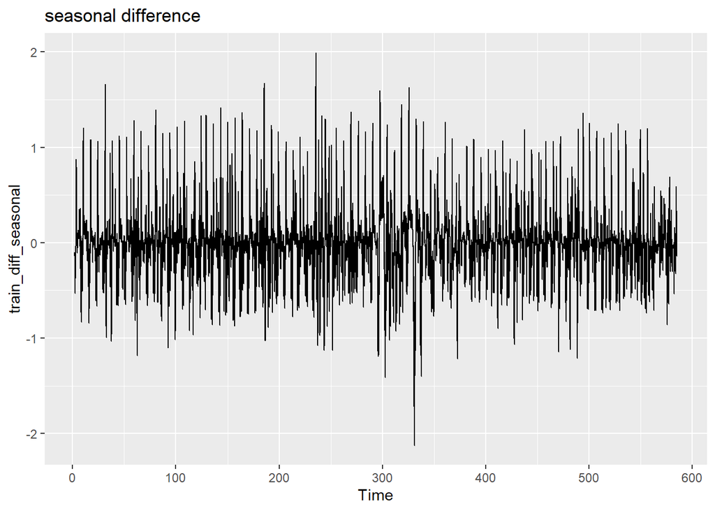

```
##
##  Box-Ljung test
##
## data:  train_diff_seasonal
## X-squared = 12520, df = 1, p-value < 2.2e-16
```

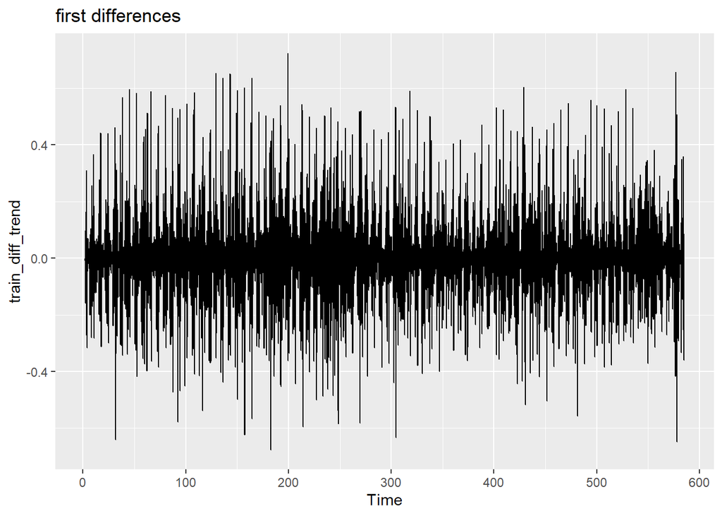

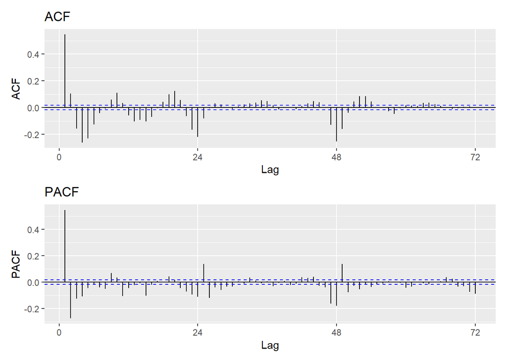